# Analysis of Minnesota Vikings Subreddit

# Introduction

Vikings Fandom has character all it’s own, formed by years of story lines, memes, and mostly pain that the fanbase has experienced together. This report delves into the vibrant and passionate conversations that unfold among Vikings fans annually, aiming to uncover the key themes and narratives that shape their community.

Understanding these questions is not only interesting but essential for capturing the pulse of Vikings fandom. Each season’s discourse reflects the collective sentiment, aspirations, and reactions of a dedicated fan base, providing a rich tapestry of social and cultural insights. Analyzing these themes helps us understand how sports influence community identity, emotional engagement, and social interactions.

Through this study, we aim to enrich the understanding of sports fan communities, offering insights that extend beyond the realm of football. This research not only sheds light on the cultural fabric of Vikings fandom but also provides a model for analyzing fan engagement across different sports and regions.

# R libraries and load raw datasets

```r
library(tidyverse)
library(tidytext)
library(scales)
library(lubridate)
library(skimr)
library(topicmodels)
library(lsa)
library(rvest)
library(topicdoc)
library(future)
library(furrr)

# Load datasets
mn_vikes_posts_raw = read_csv("data/processed/minnesotavikings_submissions.csv")
mn_vikes_comments_raw = read_csv("data/processed/minnesotavikings_comments.csv")
mn_vikes_record_raw = read_csv("data/processed/vikings_records.csv")
```

```
## ──────────────────────────────────────────────────────── Delimiter: "," chr
## (9): Lg, Tm, Div. Finish, Playoffs, Coaches, AV, Passer, Rusher, Receiver dbl
## (20): Year, W, L, T, PF, PA, PD, Pts...17, Yds...18, Pts...19, Yds...20,...
```

# Functions

```r
# Function to remove outliers in a column
remove_outliers <- function(df, column) {
  Q1 <- quantile(df[[column]], 0.25)
  Q3 <- quantile(df[[column]], 0.75)
  IQR <- Q3 - Q1

  df_filtered <- df %>%
    filter(df[[column]] >= (Q1 - 1.5 * IQR) & df[[column]] <= (Q3 + 1.5 * IQR))

  return(df_filtered)
}


# Function to add the Football season
add_football_season <- function(df, start_month = 9) {
  df <- df %>%
    mutate(
      # Parse the created column as date, handling potential parsing issues
      created_date = ymd_hms(created, quiet = TRUE),
      year = year(created_date),
      month = month(created_date),
      # Handle NA values in the created_date gracefully
      season_start_year = if_else(!is.na(created_date) & month >= start_month, year, year - 1)
    ) %>%
    # Filter out rows with NA season_start_year
    filter(!is.na(season_start_year)) %>%
    mutate(
      football_season = paste(season_start_year, season_start_year + 1, sep = "-")
    ) %>%
    select(-created_date, -year, -month)

  return(df)
}
```

# Data Description

This data was gathered from this [post](https://www.reddit.com/r/pushshift/comments/1akrhg3/separate_dump_files_for_the_top_40k_subreddits/).

There are three datasets: - MN Vikings Subreddit Posts: Contains posts made on the Minnesota Vikings subreddit. - MN Vikings Subreddit Comments: Contains comments made on the Minnesota Vikings subreddit. - MN Vikings Records: Contains historical performance data of the Minnesota Vikings team.

First lets cover the MN Vikings Subreddit Posts. We’ll perform EDA once we’ve run through all three datasets.

### MN Vikings Subreddit Posts dataset description

##### Summary of `mn_vikes_posts` Columns

- **author**: The username of the Reddit user who posted the comment.
- **title**: The title of the post made by the user.
- **score**: The score of the post, which is the net upvotes minus downvotes.
- **created**: The timestamp when the post was created.
- **link**: The URL link to the specific comment on Reddit.
- **text**: The text content of the post.
- **url**: The URL link to any external content referenced in the post.

```r
head(mn_vikes_posts_raw)
```

| author | title | score | created | link | text | url |
| --- | --- | --- | --- | --- | --- | --- |
| u/swampsparrow | Running back Adrian Peterson has been nominated for this week’s FexEx ground player of the week | 2 | 2008-11-11 21:07:00 | https://www.reddit.com/r/minnesotavikings/comments/7ctfi/running_back_adrian_peterson_has_been_nominated/ | NA | http://blogs.startribune.com/vikingsblog/?p=2142 |
| u/swampsparrow | Greenway at last is playing up to draft-day expectations | 1 | 2008-11-14 07:33:00 | https://www.reddit.com/r/minnesotavikings/comments/7dda7/greenway_at_last_is_playing_up_to_draftday/ | NA | http://www.twincities.com/ci_10959079 |
| u/[deleted] | The four-game suspensions for Vikings defensive tackles Pat and Kevin Williams have been upheld. | 1 | 2008-12-02 15:35:00 | https://www.reddit.com/r/minnesotavikings/comments/7gz2o/the_fourgame_suspensions_for_vikings_defensive/ | [deleted] | http://blogs.startribune.com/vikingsblog/?p=2228 |
| u/[deleted] | The four-game suspensions for Vikings defensive tackles Pat and Kevin Williams have been upheld. | 1 | 2008-12-02 16:46:00 | https://www.reddit.com/r/minnesotavikings/comments/7gzie/the_fourgame_suspensions_for_vikings_defensive/ | [deleted] | http://blogs.startribune.com/vikingsblog/?p=2228 |
| u/swampsparrow | The four-game suspensions for Vikings defensive tackles Pat and Kevin Williams have been upheld | 1 | 2008-12-03 07:01:00 | https://www.reddit.com/r/minnesotavikings/comments/7h3xh/the_fourgame_suspensions_for_vikings_defensive/ | NA | http://blogs.startribune.com/vikingsblog/?p=2228 |
| u/[deleted] | Vikings' Williamses get restraining orders against suspensions | 1 | 2008-12-04 08:06:00 | https://www.reddit.com/r/minnesotavikings/comments/7hcsd/vikings_williamses_get_restraining_orders_against/ | [deleted] | http://sports.espn.go.com/nfl/news/story?id=3743006 |

```r
skim(mn_vikes_posts_raw)
```

Data summary

| Name | mn_vikes_posts_raw |
| --- | --- |
| Number of rows | 164270 |
| Number of columns | 7 |
| _______________________ |  |
| Column type frequency: |  |
| character | 5 |
| numeric | 1 |
| POSIXct | 1 |
| ________________________ |  |
| Group variables | None |

**Variable type: character**

| skim_variable | n_missing | complete_rate | min | max | empty | n_unique | whitespace |
| --- | --- | --- | --- | --- | --- | --- | --- |
| author | 0 | 1.00 | 5 | 22 | 0 | 26876 | 0 |
| title | 0 | 1.00 | 1 | 305 | 0 | 157073 | 0 |
| link | 0 | 1.00 | 59 | 110 | 0 | 164270 | 0 |
| text | 85015 | 0.48 | 1 | 39999 | 0 | 53149 | 4 |
| url | 2417 | 0.99 | 4 | 1490 | 0 | 159644 | 0 |

**Variable type: numeric**

| skim_variable | n_missing | complete_rate | mean | sd | p0 | p25 | p50 | p75 | p100 | hist |
| --- | --- | --- | --- | --- | --- | --- | --- | --- | --- | --- |
| score | 0 | 1 | 57.76 | 187.35 | 0 | 1 | 11 | 47 | 36692 | ▇▁▁▁▁ |

**Variable type: POSIXct**

| skim_variable | n_missing | complete_rate | min | max | median | n_unique |
| --- | --- | --- | --- | --- | --- | --- |
| created | 0 | 1 | 2008-11-11 21:07:00 | 2023-12-31 16:59:00 | 2018-11-11 20:04:00 | 152068 |

##### Summary of `mn_vikes_comments_raw` Columns

- **team_subreddit**: The subreddit where the comment was made.
- **author**: The username of the Reddit user who posted the comment.
- **score**: The score of the comment, which is the net upvotes minus downvotes.
- **created**: The timestamp when the comment was created.
- **link**: The URL link to the specific comment on Reddit.
- **body**: The text content of the comment.

```r
head(mn_vikes_comments_raw)
```

| team_subreddit | author | score | created | link | body |
| --- | --- | --- | --- | --- | --- |
| Vikings | u/Omaromar | 1 | 2011-01-05 18:44:00 | https://www.reddit.com/r/minnesotavikings/comments/eer0h/_/c1bl372/ | FUUUUUUUUUUUUUUUUUUUUUUUUUUUUUUUUUUUUUUUUUUUUUUUUUUUUUUUUUUU. |
| Vikings | u/sagejon | 2 | 2011-01-20 11:29:00 | https://www.reddit.com/r/minnesotavikings/comments/f5y38/_/c1diqmv/ | Also just announced: Jeff Davidson will be the OL coach. He is a former OC for the Panthers. |
| Vikings | u/brentathon | 1 | 2011-01-20 12:34:00 | https://www.reddit.com/r/minnesotavikings/comments/f5y38/_/c1dj28r/ | I'm pretty excited about Singletary to be honest. |
| Vikings | u/mckearney | 1 | 2011-01-20 14:12:00 | https://www.reddit.com/r/minnesotavikings/comments/f5y38/_/c1djkn4/ | I'm so excited!\n\nI can't believe our coaching staff at this point to be honest. It's ridiculous to have Mike Singletary as our LB coach(and assistant Special Teams coach), and Bill Musgrave is a mad… |
| Vikings | u/tehchoppers | 1 | 2011-01-20 15:35:00 | https://www.reddit.com/r/minnesotavikings/comments/f5y38/_/c1djz51/ | it will be interesting to see what type of a coach leslie will develop into. Really excited for the draft. |
| Vikings | u/sagejon | 3 | 2011-01-20 16:10:00 | https://www.reddit.com/r/minnesotavikings/comments/f5y38/_/c1dk4sf/ | This begs the question, where to head in the draft...\n\nI would like to see the Vikes trade down (into the 20s) and work on OL. With FS a high priority after that. Madieu Willaims needs to go!\n\nMos… |

Now lets use the built in summary function to view the dataset as well.

The score/karma ranges from -499 to 5,245. The comment created date ranges from Jan 2011 to December 2023. **Note that the first season and last season are cut in half.**

```r
skim(mn_vikes_comments_raw)
```

Data summary

| Name | mn_vikes_comments_raw |
| --- | --- |
| Number of rows | 4427415 |
| Number of columns | 6 |
| _______________________ |  |
| Column type frequency: |  |
| character | 4 |
| numeric | 1 |
| POSIXct | 1 |
| ________________________ |  |
| Group variables | None |

**Variable type: character**

| skim_variable | n_missing | complete_rate | min | max | empty | n_unique | whitespace |
| --- | --- | --- | --- | --- | --- | --- | --- |
| team_subreddit | 0 | 1 | 7 | 7 | 0 | 1 | 0 |
| author | 0 | 1 | 5 | 26 | 0 | 92624 | 0 |
| link | 0 | 1 | 67 | 118 | 0 | 4426459 | 0 |
| body | 52 | 1 | 1 | 10237 | 0 | 3983677 | 1 |

**Variable type: numeric**

| skim_variable | n_missing | complete_rate | mean | sd | p0 | p25 | p50 | p75 | p100 | hist |
| --- | --- | --- | --- | --- | --- | --- | --- | --- | --- | --- |
| score | 0 | 1 | 5.29 | 17.08 | -499 | 1 | 2 | 5 | 5245 | ▇▁▁▁▁ |

**Variable type: POSIXct**

| skim_variable | n_missing | complete_rate | min | max | median | n_unique |
| --- | --- | --- | --- | --- | --- | --- |
| created | 0 | 1 | 2011-01-05 18:44:00 | 2023-12-31 16:59:00 | 2020-01-11 15:56:00 | 1952025 |

Now lets do the same for the the vikings records dataset, which ranges from 1961 to 2023.

##### Summary of `mn_vikes_record` Columns

- **Year**: The year the NFL season took place.
- **Lg**: The league in which the team played (e.g., NFL).
- **Tm**: The name of the team (Minnesota Vikings).
- **W**: The number of wins the team had in that season.
- **L**: The number of losses the team had in that season.
- **T**: The number of ties the team had in that season.
- **Div. Finish**: The team’s finishing position within their division.
- **Playoffs**: The playoff result for the team (e.g., Lost WC (Wildcard), Lost Div (Divisional), Lost Conf (Conference), etc.).
- **PF (Points For)**: The total number of points the team scored in that season.
- **PA (Points Against)**: The total number of points the team allowed in that season.
- **PD (Point Differential)**: The difference between points scored (PF) and points allowed (PA).
- **Coaches**: The head coach or coaches of the team during that season.
- **AV (Approximate Value)**: An approximate value metric for player performance.
- **Passer**: The main quarterback or passer for the team.
- **Rusher**: The main running back or rusher for the team.
- **Receiver**: The main wide receiver or receiver for the team.
- **Pts (Points)**: Offensive points scored by the team (can also refer to top players’ points).
- **Yds (Yards)**: Offensive yards gained by the team.
- **Pts (Points)**: Defensive points allowed by the team.
- **Yds (Yards)**: Defensive yards allowed by the team.
- **T/G (Turnovers/Game)**: Average turnovers per game by the team.
- **Pts± (Points Differential)**: Points differential metric.
- **Yds± (Yards Differential)**: Yards differential metric.
- **out of**: Total number of teams in the league/division.
- **MoV (Margin of Victory)**: Average margin of victory.
- **SoS (Strength of Schedule)**: Strength of schedule metric.
- **SRS (Simple Rating System)**: Combined rating of team performance including offense and defense.
- **OSRS (Offensive SRS)**: Offensive Simple Rating System metric.
- **DSRS (Defensive SRS)**: Defensive Simple Rating System metric.

```r
head(mn_vikes_record_raw)
```

| Year | Lg | Tm | W | L | T | Div. Finish | Playoffs | PF | PA | PD | Coaches | AV | Passer | Rusher | Receiver | Pts...17 | Yds...18 | Pts...19 | Yds...20 | T/G | Pts± | Yds± | out of | MoV | SoS | SRS | OSRS | DSRS |
| --- | --- | --- | --- | --- | --- | --- | --- | --- | --- | --- | --- | --- | --- | --- | --- | --- | --- | --- | --- | --- | --- | --- | --- | --- | --- | --- | --- | --- |
| 2023 | NFL | Minnesota Vikings | 7 | 10 | 0 | 3rd of 4 | NA | 344 | 362 | -18 | O'Connell | Hunter | Cousins | Mattison | Jefferson | 22 | 10 | 13 | 16 | 30 | 17 | 10 | 32 | -1.1 | 0.5 | -0.6 | -1.6 | 1.0 |
| 2022 | NFL | Minnesota Vikings* | 13 | 4 | 0 | 1st of 4 | Lost WC | 424 | 427 | -3 | O'Connell | Jefferson | Cousins | Cook | Jefferson | 8 | 7 | 28 | 31 | 12 | 15 | 26 | 32 | -0.2 | 0.1 | -0.1 | 2.8 | -2.9 |
| 2021 | NFL | Minnesota Vikings | 8 | 9 | 0 | 2nd of 4 | NA | 425 | 426 | -1 | Zimmer | Jefferson | Cousins | Cook | Jefferson | 14 | 12 | 24 | 30 | 5 | 18 | 22 | 32 | -0.1 | 0.3 | 0.3 | 1.9 | -1.6 |
| 2020 | NFL | Minnesota Vikings | 7 | 9 | 0 | 3rd of 4 | NA | 430 | 475 | -45 | Zimmer | Cousins | Cousins | Cook | Jefferson | 11 | 4 | 29 | 27 | 20 | 22 | 15 | 32 | -2.8 | 0.4 | -2.4 | 1.3 | -3.8 |
| 2019 | NFL | Minnesota Vikings* | 10 | 6 | 0 | 2nd of 4 | Lost Div | 407 | 303 | 104 | Zimmer | Kendricks | Cousins | Cook | Diggs | 8 | 16 | 5 | 14 | 5 | 7 | 13 | 32 | 6.5 | -1.1 | 5.4 | 2.5 | 2.9 |
| 2018 | NFL | Minnesota Vikings | 8 | 7 | 1 | 2nd of 4 | NA | 360 | 341 | 19 | Zimmer | Hunter | Cousins | Cook | Thielen | 19 | 20 | 9 | 4 | 19 | 12 | 7 | 32 | 1.2 | -0.6 | 0.6 | -1.2 | 1.8 |

```r
skim(mn_vikes_record_raw)
```

Data summary

| Name | mn_vikes_record_raw |
| --- | --- |
| Number of rows | 64 |
| Number of columns | 29 |
| _______________________ |  |
| Column type frequency: |  |
| character | 9 |
| numeric | 20 |
| ________________________ |  |
| Group variables | None |

**Variable type: character**

| skim_variable | n_missing | complete_rate | min | max | empty | n_unique | whitespace |
| --- | --- | --- | --- | --- | --- | --- | --- |
| Lg | 1 | 0.98 | 3 | 3 | 0 | 1 | 0 |
| Tm | 1 | 0.98 | 17 | 18 | 0 | 2 | 0 |
| Div. Finish | 1 | 0.98 | 8 | 8 | 0 | 14 | 0 |
| Playoffs | 33 | 0.48 | 7 | 9 | 0 | 4 | 0 |
| Coaches | 1 | 0.98 | 4 | 17 | 0 | 12 | 0 |
| AV | 1 | 0.98 | 3 | 11 | 0 | 33 | 0 |
| Passer | 1 | 0.98 | 4 | 11 | 0 | 22 | 0 |
| Rusher | 1 | 0.98 | 4 | 9 | 0 | 24 | 0 |
| Receiver | 1 | 0.98 | 4 | 10 | 0 | 27 | 0 |

**Variable type: numeric**

| skim_variable | n_missing | complete_rate | mean | sd | p0 | p25 | p50 | p75 | p100 | hist |
| --- | --- | --- | --- | --- | --- | --- | --- | --- | --- | --- |
| Year | 1 | 0.98 | 1992.00 | 18.33 | 1961.0 | 1976.50 | 1992.0 | 2007.50 | 2023.0 | ▇▇▇▇▇ |
| W | 1 | 0.98 | 8.30 | 2.77 | 2.0 | 7.00 | 8.0 | 10.00 | 15.0 | ▂▆▇▇▁ |
| L | 1 | 0.98 | 6.90 | 2.75 | 1.0 | 5.00 | 7.0 | 9.00 | 13.0 | ▂▃▇▃▂ |
| T | 1 | 0.98 | 0.17 | 0.49 | 0.0 | 0.00 | 0.0 | 0.00 | 3.0 | ▇▁▁▁▁ |
| PF | 1 | 0.98 | 341.92 | 63.37 | 187.0 | 297.00 | 344.0 | 382.50 | 556.0 | ▂▆▇▂▁ |
| PA | 1 | 0.98 | 319.05 | 82.99 | 133.0 | 282.50 | 326.0 | 365.50 | 484.0 | ▂▂▇▆▂ |
| PD | 1 | 0.98 | 22.87 | 91.99 | -208.0 | -26.00 | 9.0 | 63.50 | 260.0 | ▁▃▇▂▁ |
| Pts…17 | 1 | 0.98 | 12.02 | 6.89 | 1.0 | 6.50 | 12.0 | 16.00 | 29.0 | ▇▇▆▅▂ |
| Yds…18 | 1 | 0.98 | 12.24 | 7.23 | 1.0 | 6.00 | 12.0 | 17.00 | 29.0 | ▇▇▆▃▂ |
| Pts…19 | 1 | 0.98 | 13.81 | 8.61 | 1.0 | 6.00 | 13.0 | 19.00 | 32.0 | ▇▆▇▂▃ |
| Yds…20 | 1 | 0.98 | 13.73 | 9.13 | 1.0 | 6.00 | 13.0 | 20.00 | 31.0 | ▇▆▆▂▅ |
| T/G | 1 | 0.98 | 12.65 | 8.96 | 1.0 | 5.00 | 11.0 | 18.50 | 31.0 | ▇▆▂▂▃ |
| Pts± | 1 | 0.98 | 12.59 | 7.13 | 1.0 | 7.50 | 13.0 | 17.00 | 28.0 | ▆▅▇▃▂ |
| Yds± | 1 | 0.98 | 12.33 | 7.75 | 1.0 | 6.00 | 12.0 | 18.00 | 29.0 | ▇▇▅▅▃ |
| out of | 1 | 0.98 | 27.59 | 5.66 | 14.0 | 28.00 | 28.0 | 32.00 | 32.0 | ▂▁▁▇▇ |
| MoV | 1 | 0.98 | 1.53 | 6.14 | -13.0 | -1.70 | 0.6 | 4.10 | 17.6 | ▁▇▇▃▁ |
| SoS | 1 | 0.98 | 0.21 | 1.82 | -5.2 | -1.05 | 0.2 | 1.15 | 6.5 | ▁▅▇▂▁ |
| SRS | 1 | 0.98 | 1.75 | 5.70 | -10.9 | -2.00 | 0.9 | 5.60 | 17.6 | ▂▇▇▃▁ |
| OSRS | 1 | 0.98 | 1.43 | 3.25 | -4.5 | -0.85 | 1.4 | 3.30 | 13.2 | ▅▇▅▁▁ |
| DSRS | 1 | 0.98 | 0.31 | 4.05 | -8.2 | -2.10 | 0.3 | 2.50 | 10.6 | ▂▆▇▃▁ |

# EDA

Prior to EDA, lets add some useful columns like the season the post/comment was posted under.

```r
# Create Prep datasets
mn_vikes_posts_prep <- mn_vikes_posts_raw
mn_vikes_comments_prep <- mn_vikes_comments_raw
mn_vikes_record_prep <- mn_vikes_record_raw

# Convert the 'created' column to datetime
mn_vikes_posts_prep$created <- ymd_hms(mn_vikes_posts_prep$created)
mn_vikes_comments_prep$created <- ymd_hms(mn_vikes_comments_prep$created)
# Extract year and month for grouping
mn_vikes_posts_prep <- mn_vikes_posts_prep %>%
  mutate(year_month = floor_date(created, "month"))
mn_vikes_comments_prep <- mn_vikes_comments_prep %>%
  mutate(year_month = floor_date(created, "month"))

# Add the football season
mn_vikes_posts_prep <- add_football_season(mn_vikes_posts_prep, start_month=9)
mn_vikes_comments_prep <- add_football_season(mn_vikes_comments_prep, start_month=9)

# Remove rows with missing or invalid dates
mn_vikes_posts_prep <- mn_vikes_posts_prep[!is.na(mn_vikes_posts_prep$created), ]
mn_vikes_comments_prep <- mn_vikes_comments_prep[!is.na(mn_vikes_comments_prep$created), ]

# Refresh stop words
stop_words <- get_stopwords()

# Create custom list of stop words to remove generic terms.
stop_words_mn_vikes <- c("game", "football", "team", "vikings", "season", "year",
                         "time", "qb", "play","just", "can", "one", "get", "like", "now", "fan",
                         "week", "new", "today", "first", "last", "think", "anyone", "vs",
                         "us", "bank", "going", "next", "got", "know", "it's","see", "much",
                         "back", "well", "right", "also", "make", "bad", "way","really",
                         "still", "deleted", "take", "https", "guys", "go", "day", "games",
                         "good", "better", "need", "want", "lol", "say", "every")

# Create tidy dataset and remove stop words, custom stop words, and numbers and digits.
mn_vikes_posts_tidy <- mn_vikes_posts_prep %>%
  unnest_tokens(input = title,
                output = word) %>%
  anti_join(stop_words) %>%
  filter(!word %in% stop_words_mn_vikes) %>%
  filter(!grepl("^[-+]?\\s*(\\d+[.,])?\\d*(\\.[0-9]+)?([eEs][+-]?\\d+)?\\s*$", trimws(word)))
# Create tidy dataset and remove stop words, custom stop words, and numbers and digits.
mn_vikes_comments_tidy <- mn_vikes_comments_prep %>%
  unnest_tokens(input = body,
                output = word) %>%
  anti_join(stop_words) %>%
  filter(!word %in% stop_words_mn_vikes) %>%
  filter(!grepl("^[-+]?\\s*(\\d+[.,])?\\d*(\\.[0-9]+)?([eEs][+-]?\\d+)?\\s*$", trimws(word)))
```

### For both our Posts and Comments, what’s the volume of examples that we’re working with?

It’s worth remembering their are partial seasons in both datasets. - Posts: November 2008 to December 2023 - Comments: January 2011 to December 2023

##### Posts

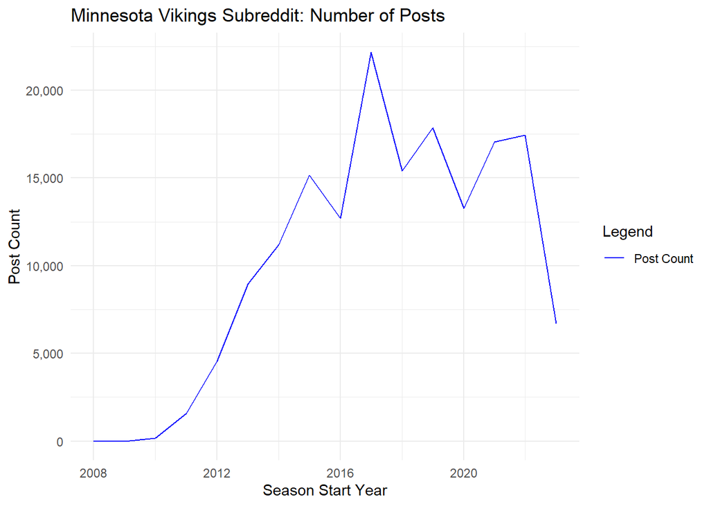

```r
# Group by year_month to get the count of comments and average score
time_series_post_df <- mn_vikes_posts_prep %>%
  group_by(season_start_year) %>%
  summarise(
    post_count = n(),
    average_score = mean(score, na.rm = TRUE)
  )

# Plotting the results
ggplot(time_series_post_df, aes(x = season_start_year)) +
  geom_line(aes(y = post_count, color = "Post Count")) +
  labs(
    title = "Minnesota Vikings Subreddit: Number of Posts",
    x = "Season Start Year",
    y = "Post Count"
  ) +
  theme_minimal() +
  scale_color_manual(
    name = "Legend",
    values = c("Post Count" = "blue")
  ) +
  scale_y_continuous(labels = comma)
```

2017, a year when the Vikings had a great record (13-3) and made it to the NFC Championship, is the peak. This season include Case Keenum’s throw to [Diggs, Sideline, Touchdown](https://www.youtube.com/watch?v=dzRRi2QcSEM) to beat the Saints walk-off style, arguably the greatest Vikings moment in recent memory. In true Vikings fashion, they let us down in the next game versus the Eagles, to this day I have not re watched it. It was an emotional high to a hopeless loss.

The subreddit hasn’t reached that peak again, even in 2022 when we had a similar record of (13-4). In that year we were regarded as fraudulent, and our first-round exit against the Daniel Jones led Giants didn’t help that narrative.

Note that this activity differs from the number of comments, which have been generally trending upwards since the subreddit’s creation.

##### Comments:

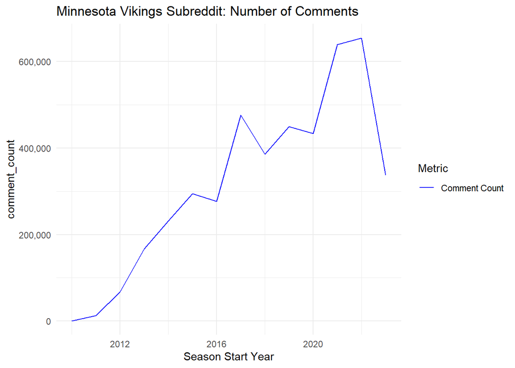

```r
# Group by year_month to get the count of comments and average score
time_series_comments_df <- mn_vikes_comments_prep %>%
  group_by(season_start_year) %>%
  summarise(
    comment_count = n(),
    average_score = mean(score, na.rm = TRUE)
  )

# Plotting the results
ggplot(time_series_comments_df, aes(x = season_start_year)) +
  geom_line(aes(y = comment_count, color = "Comment Count")) +
  scale_y_continuous(
    name = "Count/Score",
    sec.axis = sec_axis(~., name = "Average Score")
  ) +
  labs(
    title = "Minnesota Vikings Subreddit: Number of Comments",
    x = "Season Start Year"
  ) +
  theme_minimal() +
  scale_color_manual(
    name = "Metric",
    values = c("Comment Count" = "blue")
  ) +
  scale_y_continuous(labels = comma)
```

### Next I’m curious about the score’s of the posts and comments.

Is there a significant amount of posts and comments with positive karma that we can learn from? Given the descriptive statistics of the points in the skim outputs above, lets remove outliers from both.

##### Posts

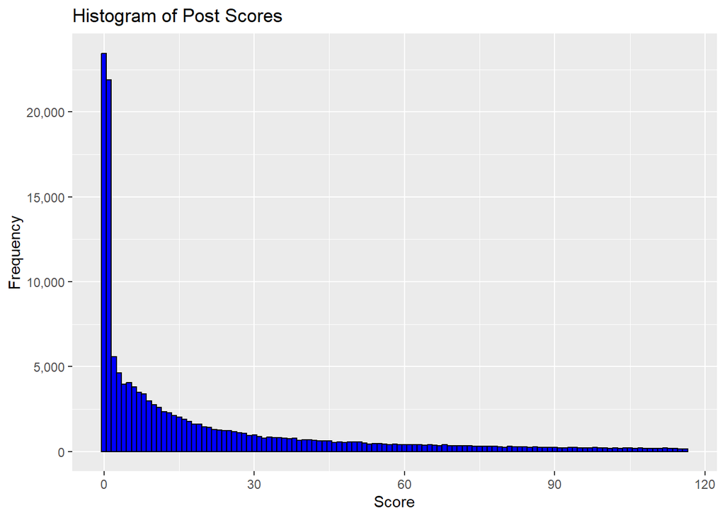

```r
# Histogram of a numerical column
mn_vikes_posts_prep %>%
  remove_outliers("score") %>%
  ggplot(aes(x = score)) +
  geom_histogram(binwidth = 1, fill = "blue", color = "black") +
  labs(title = "Histogram of Post Scores",
       x = "Score",
       y = "Frequency") +
  scale_y_continuous(labels = comma)
```

##### Comments

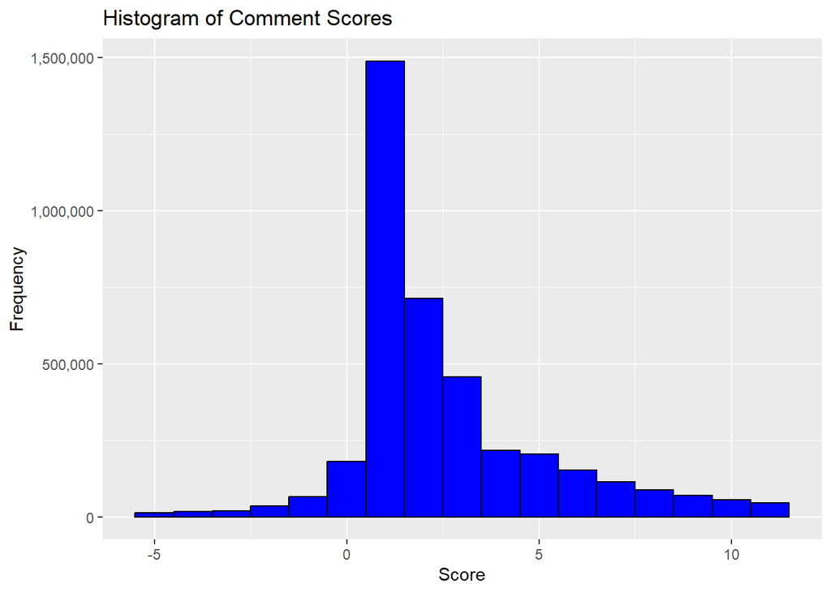

```r
# Histogram of a numerical column
mn_vikes_comments_prep %>%
  remove_outliers("score") %>%
  ggplot(aes(x = score)) +
  geom_histogram(binwidth = 1, fill = "blue", color = "black") +
  labs(title = "Histogram of Comment Scores",
       x = "Score",
       y = "Frequency") +
  scale_y_continuous(labels = comma)
```

### Next lets take a quick look at the most popular words in the Posts and Comments.

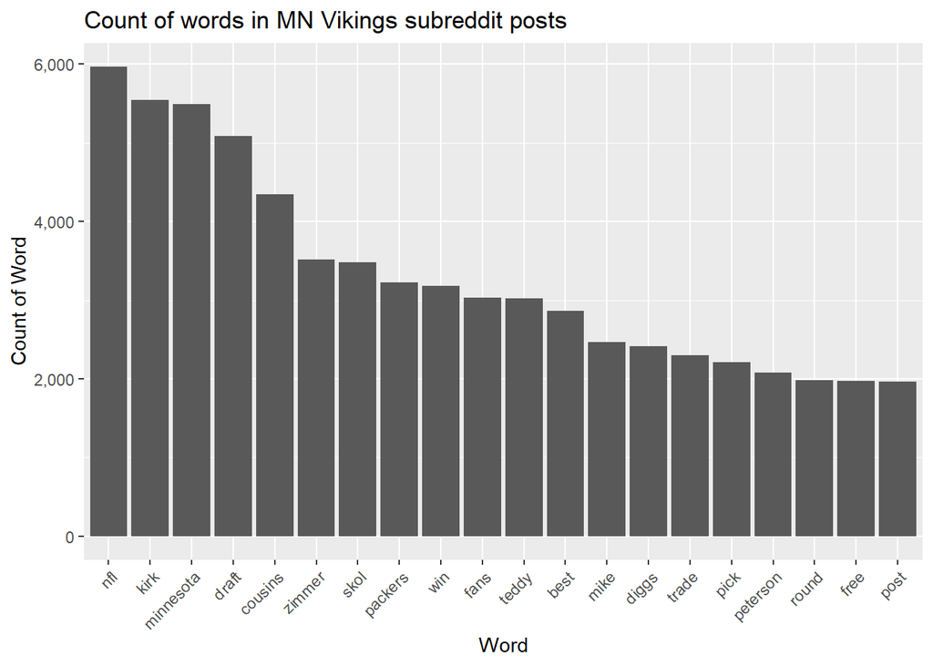

```r
mn_vikes_post_dist <- mn_vikes_posts_tidy %>%
  select(word) %>%
  group_by(word) %>%
  summarize(n = n())

# There are a ton of words that are just numbers or variations of numbers (e.g., 0,0,0,0,0,0,0), so this gets rid of most of them.
mn_vikes_post_dist %>%
  top_n(n=20, wt=n) %>%
  ggplot(aes(x=reorder(word, n), y=n)) +
  geom_col() +
  scale_x_discrete(limits = rev) +
  labs(title="Count of words in MN Vikings subreddit posts",
       x="Word",
       y="Count of Word") +
  theme(axis.text.x = element_text(angle = 45, hjust = 1)) +
  scale_y_continuous(labels = comma)
```

Here we see a few common football terms, players, and coaches make up the majority of the terms used in the subreddit.

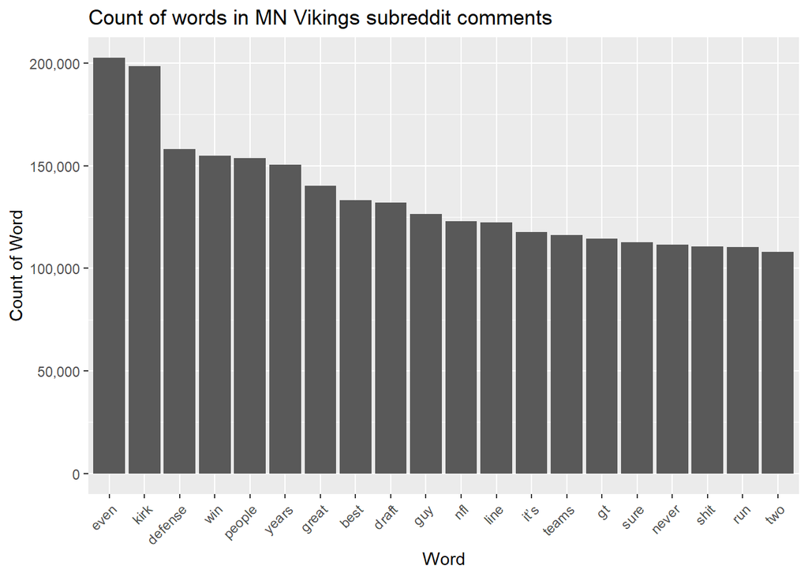

```r
mn_vikes_comments_dist <- mn_vikes_comments_tidy %>%
  select(word) %>%
  group_by(word) %>%
  summarize(n = n())

# There are a ton of words that are just numbers or variations of numbers (e.g., 0,0,0,0,0,0,0), so this gets rid of most of them.
mn_vikes_comments_dist %>%
  top_n(n=20, wt=n) %>%
  ggplot(aes(x=reorder(word, n), y=n)) +
  geom_col() +
  scale_x_discrete(limits = rev) +
  labs(title="Count of words in MN Vikings subreddit comments",
       x="Word",
       y="Count of Word") +
  theme(axis.text.x = element_text(angle = 45, hjust = 1)) +
  scale_y_continuous(labels = comma)
```

The comments are less focused on the team’s players, with more discussion about the performance of the team.

## Data Analysis

Lets first take a look at the sentiment of posts and comments by season start year.

```r
# Taking a look at the
mn_vikes_sentiment <- mn_vikes_posts_tidy %>%
  select(season_start_year, word) %>%
  inner_join(get_sentiments(),
             relationship = "many-to-many") %>%
  group_by(season_start_year, sentiment) %>%
  summarize(n = n()) %>%
  filter(season_start_year != 2011)
```

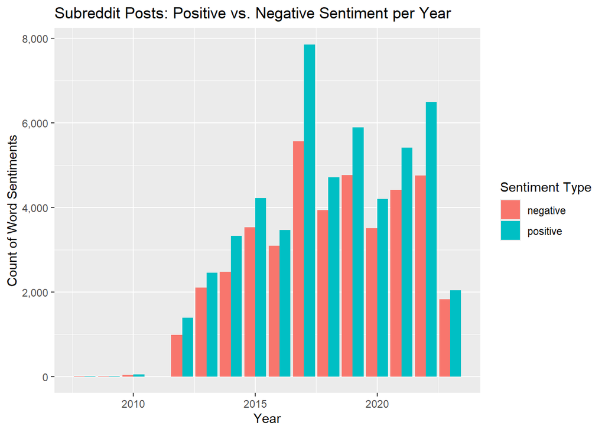

```r
mn_vikes_sentiment %>%
  ggplot(aes(x=season_start_year, y=n, fill=sentiment)) +
  geom_col(position="dodge") +
  labs(title="Subreddit Posts: Positive vs. Negative Sentiment per Year",
       x="Year",
       y="Count of Word Sentiments",
       fill="Sentiment Type") +
  scale_y_continuous(labels = comma)
```

```r
# Taking a look at the
mn_vikes_sentiment_comments <- mn_vikes_comments_tidy %>%
  select(season_start_year, word) %>%
  inner_join(get_sentiments(),
             relationship = "many-to-many") %>%
  group_by(season_start_year, sentiment) %>%
  summarize(n = n()) %>%
  filter(season_start_year != 2011)
```

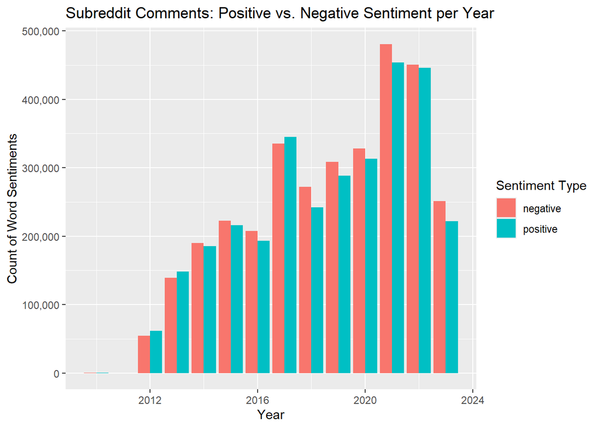

```r
mn_vikes_sentiment_comments %>%
  ggplot(aes(x=season_start_year, y=n, fill=sentiment)) +
  geom_col(position="dodge") +
  labs(title="Subreddit Comments: Positive vs. Negative Sentiment per Year",
       x="Year",
       y="Count of Word Sentiments",
       fill="Sentiment Type") +
  scale_y_continuous(labels = comma)
```

Comments seems to be much closer in sentiment that posts. This could be a reflection of how positive post titles are typically encouraged by the community (via score) whereas the discussion itself can be more nuanced.

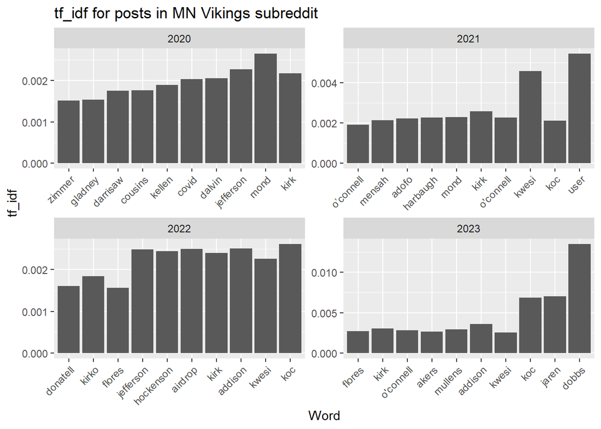

```r
mn_vikes_posts_tf_idf <- mn_vikes_posts_tidy %>%
  count(season_start_year, word) %>%
  filter(season_start_year != 2011) %>% # 2011 only has one comment and is therefore not very interesting
  bind_tf_idf(term = word,
              document = season_start_year,
              n=n) %>%
  group_by(season_start_year) %>%
  top_n(n=10,
        wt = tf_idf) %>%
  filter(between(season_start_year, 2020, 2023))

mn_vikes_posts_tf_idf %>%
  ggplot() +
  geom_col(aes(x = reorder(word,tf_idf),
               y = tf_idf)) +
  facet_wrap(~season_start_year,
            scales = "free") +
  labs(title="tf_idf for posts in MN Vikings subreddit",
       x="Word",
       y="tf_idf") +
  theme(axis.text.x = element_text(angle = 45, hjust = 1)) +
  scale_y_continuous(labels = comma)
```

Overall the posts are dominated by the players, coaches, and GMs that season. With the season determining which players, coaches, and GMs are being discussed.

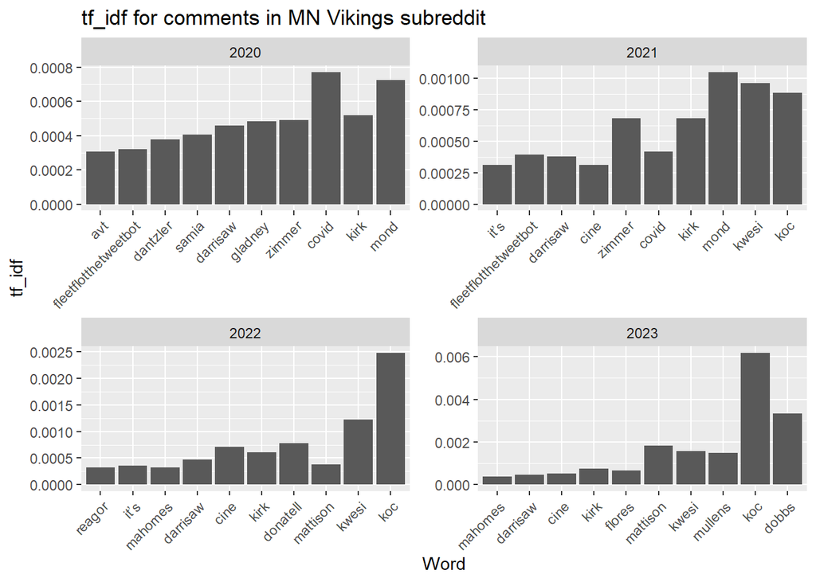

```r
mn_vikes_comments_tf_idf <- mn_vikes_comments_tidy %>%
  count(season_start_year, word) %>%
  filter(season_start_year != 2011) %>% # 2011 only has one comment and is therefore not very interesting
  bind_tf_idf(term = word,
              document = season_start_year,
              n=n) %>%
  group_by(season_start_year) %>%
  top_n(n=10,
        wt = tf_idf) %>%
  filter(between(season_start_year, 2020, 2023))

mn_vikes_comments_tf_idf %>%
  ggplot() +
  geom_col(aes(x = reorder(word,tf_idf),
               y = tf_idf)) +
  facet_wrap(~season_start_year,
            scales = "free") +
  labs(title="tf_idf for comments in MN Vikings subreddit",
       x="Word",
       y="tf_idf") +
  theme(axis.text.x = element_text(angle = 45, hjust = 1)) +
  scale_y_continuous(labels = comma)
```

We see a very similar pattern in the comments.

Now lets look at the beta values for the posts.

```r
# Get count of words in posts
post_word_count <-  mn_vikes_posts_tidy %>%
   anti_join(stop_words) %>% #remove stop words
  count(season_start_year,word,sort=T)
```

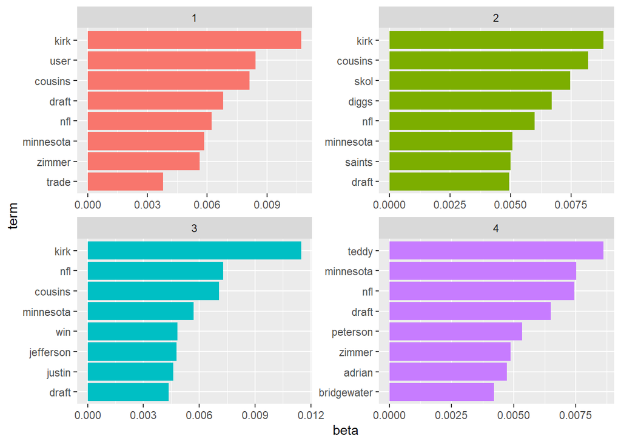

```r
# Create Posts DTM
posts_dtm <- post_word_count %>%
  cast_dtm(document = season_start_year,
           term = word,
           value = n)

# Start LDA Analysis
posts_lda <- LDA(posts_dtm, k = 4,
                    control = list(seed = 1234))

# Grab the topic-word probabilities
chapter_topics <- tidy(posts_lda,
                       matrix = "beta")

# Grab the top words from each topic
top_post_terms <- chapter_topics %>%
  group_by(topic) %>%
  slice_max(beta, n = 8) %>%
  ungroup() %>%
  arrange(topic, -beta)

# View the results
top_post_terms %>%
  mutate(term = reorder_within(term, beta, topic)) %>%
  ggplot(aes(x = beta, y = term, fill = factor(topic))) +
  geom_col(show.legend = FALSE) +
  facet_wrap(~topic  , scales = "free" ) +
  scale_y_reordered()
```

Now lets do the same for the comments.

```r
# Get count of words in posts
comment_word_count <-  mn_vikes_comments_tidy %>%
   anti_join(stop_words) %>% #remove stop words
  count(season_start_year,word,sort=T)
```

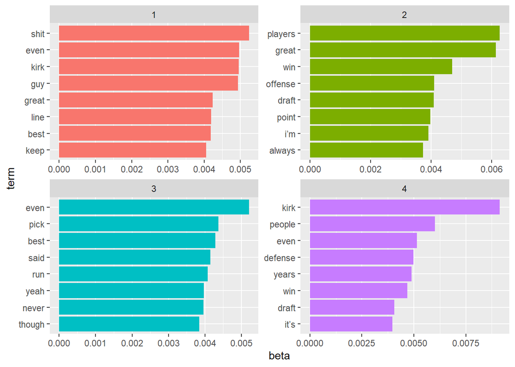

```r
# Create Posts DTM
comments_dtm <- comment_word_count %>%
  cast_dtm(document = season_start_year,
           term = word,
           value = n)

# Start LDA Analysis
comments_lda <- LDA(comments_dtm, k = 4,
                    control = list(seed = 1234))

# Grab the topic-word probabilities
comment_topics <- tidy(comments_lda,
                       matrix = "beta")

# Grab the top words from each topic
top_comment_terms <- comment_topics %>%
  group_by(topic) %>%
  slice_max(beta, n = 8) %>%
  ungroup() %>%
  arrange(topic, -beta)

# View the results
top_comment_terms %>%
  mutate(term = reorder_within(term, beta, topic)) %>%
  ggplot(aes(x = beta, y = term, fill = factor(topic))) +
  geom_col(show.legend = FALSE) +
  facet_wrap(~topic  , scales = "free" ) +
  scale_y_reordered()
```

# Conclusion

Overall, it was challenging to identify consistent themes in the discussions among Vikings fans over the years. The discourse is predominantly centered around players, coaches, and general managers, which logically aligns with their direct impact on the outcomes of games. For the next phase of this analysis, I propose three approaches to delve deeper into the data:

- **Refine the Analysis by Removing Common Entities**: The first approach would involve enhancing the stop words list to include names of players, coaches, and general managers. This would help uncover underlying themes and discussions that are overshadowed by the frequent mentions of these key figures.
- **Focus on Player-Specific Discussions**: The second approach would involve isolating comments and posts that mention specific players. By examining the context and nature of discussions around each player, we can gain insights into fan perceptions, sentiments, and the impact of individual players on fan engagement.
- **Analyze Game-Specific Threads**: The third approach would focus on discussions related to individual games. By incorporating data such as win probability, game statistics, and critical moments, we can analyze how game outcomes and in-game events influence fan discussions and sentiments.

This exercise has been a highly enjoyable dive into a community I have been part of my entire life. It has provided valuable insights into the complexities and challenges of analyzing a large corpus of text data. Through these proposed next steps, we can aim to uncover deeper insights and more nuanced understanding of the discussions among Vikings fans.

Engaging in this analysis has not only deepened my appreciation for the community but also highlighted the intricacies involved in text analysis. The dynamic and multifaceted nature of fan discussions poses unique challenges, yet also offers a rich landscape for exploration. Through continued refinement and targeted analyses, we can aim to uncover more meaningful insights and contribute to a greater understanding of the community’s discourse.

# Citation

Data prior to April 2023 was collected by Pushshift, data after that was collected by u/raiderbdev [here](https://www.reddit.com/user/raiderbdev). Extracted, split, and re-packaged by me, u/Watchful1. Hosted on academictorrents.com.